# Part I - (Ford GoBike System Data)

## Introduction

This data set includes information about individual rides made in a bike-sharing system covering the greater San Francisco Bay area.

> **Brief description about the data**:

```
    Trip Duration (seconds)

    Start Time and Date

    End Time and Date

    Start Station ID

    Start Station Name

    Start Station Latitude

    Start Station Longitude

    End Station ID

    End Station Name

    End Station Latitude

    End Station Longitude

    Bike ID

    User Type (“Subscriber” = Member or “Customer” = Casual)

    Member Year of Birth

    Member Gender

    Bike Share for all Trip
```

## Preliminary Wrangling

```python
# import all packages and set plots to be embedded inline
import numpy as np
import pandas as pd
import matplotlib.pyplot as plt
import seaborn as sb

%matplotlib inline
```

> Load in your dataset and describe its properties through the questions below. Try and motivate your exploration goals through this section.

```python
# read data_set and make copy to save it
df1 = pd.read_csv("201902-fordgobike-tripdata.csv")
df = df1.copy()
```

```python
#display the first 5 rows
df.head()
```

|  | duration_sec | start_time | end_time | start_station_id | start_station_name | start_station_latitude | start_station_longitude | end_station_id | end_station_name | end_station_latitude | end_station_longitude | bike_id | user_type | member_birth_year | member_gender | bike_share_for_all_trip |
| --- | --- | --- | --- | --- | --- | --- | --- | --- | --- | --- | --- | --- | --- | --- | --- | --- |
| 0 | 52185 | 2019-02-28 17:32:10.1450 | 2019-03-01 08:01:55.9750 | 21.0 | Montgomery St BART Station (Market St at 2nd St) | 37.789625 | -122.400811 | 13.0 | Commercial St at Montgomery St | 37.794231 | -122.402923 | 4902 | Customer | 1984.0 | Male | No |
| 1 | 42521 | 2019-02-28 18:53:21.7890 | 2019-03-01 06:42:03.0560 | 23.0 | The Embarcadero at Steuart St | 37.791464 | -122.391034 | 81.0 | Berry St at 4th St | 37.775880 | -122.393170 | 2535 | Customer | NaN | NaN | No |
| 2 | 61854 | 2019-02-28 12:13:13.2180 | 2019-03-01 05:24:08.1460 | 86.0 | Market St at Dolores St | 37.769305 | -122.426826 | 3.0 | Powell St BART Station (Market St at 4th St) | 37.786375 | -122.404904 | 5905 | Customer | 1972.0 | Male | No |
| 3 | 36490 | 2019-02-28 17:54:26.0100 | 2019-03-01 04:02:36.8420 | 375.0 | Grove St at Masonic Ave | 37.774836 | -122.446546 | 70.0 | Central Ave at Fell St | 37.773311 | -122.444293 | 6638 | Subscriber | 1989.0 | Other | No |
| 4 | 1585 | 2019-02-28 23:54:18.5490 | 2019-03-01 00:20:44.0740 | 7.0 | Frank H Ogawa Plaza | 37.804562 | -122.271738 | 222.0 | 10th Ave at E 15th St | 37.792714 | -122.248780 | 4898 | Subscriber | 1974.0 | Male | Yes |

```python
print('The number of rows we have in this dataset is:', df.shape[0],
      'However the number of columns is:', df.shape[1])
```

```
The number of rows we have in this dataset is: 183412 However the number of columns is: 16
```

```python
#checking for duplicates
print('The number of duplicate records we have in the dataset is',df.duplicated().sum())
```

```
The number of duplicate records we have in the dataset is 0
```

```python
#overview of data types
print(df.dtypes)
```

```
duration_sec                 int64
start_time                  object
end_time                    object
start_station_id           float64
start_station_name          object
start_station_latitude     float64
start_station_longitude    float64
end_station_id             float64
end_station_name            object
end_station_latitude       float64
end_station_longitude      float64
bike_id                      int64
user_type                   object
member_birth_year          float64
member_gender               object
bike_share_for_all_trip     object
dtype: object
```

```python
#checking for any null values in the dataset
df.isna().sum()
```

```
duration_sec                  0
start_time                    0
end_time                      0
start_station_id            197
start_station_name          197
start_station_latitude        0
start_station_longitude       0
end_station_id              197
end_station_name            197
end_station_latitude          0
end_station_longitude         0
bike_id                       0
user_type                     0
member_birth_year          8265
member_gender              8265
bike_share_for_all_trip       0
dtype: int64
```

> **Introductory cleaning**

There are some quality issues that need to be cleaned :

Missing values(start_station_id, start_station_name, end_station_id, end_station_name, member_birth_year, member_gender)

Start/end times are not in the timestamp format

The following columns are not in object format: start_station_id, end_station_id, bike_id

Member birth is in the float format, but should be converted to integer format

```python
#dropping null values
df.dropna(inplace=True)
#checking all columns after the drop of the null values.
df.info()
```

```
<class 'pandas.core.frame.DataFrame'>
Int64Index: 174952 entries, 0 to 183411
Data columns (total 16 columns):
 #   Column                   Non-Null Count   Dtype
---  ------                   --------------   -----
 0   duration_sec             174952 non-null  int64
 1   start_time               174952 non-null  object
 2   end_time                 174952 non-null  object
 3   start_station_id         174952 non-null  float64
 4   start_station_name       174952 non-null  object
 5   start_station_latitude   174952 non-null  float64
 6   start_station_longitude  174952 non-null  float64
 7   end_station_id           174952 non-null  float64
 8   end_station_name         174952 non-null  object
 9   end_station_latitude     174952 non-null  float64
 10  end_station_longitude    174952 non-null  float64
 11  bike_id                  174952 non-null  int64
 12  user_type                174952 non-null  object
 13  member_birth_year        174952 non-null  float64
 14  member_gender            174952 non-null  object
 15  bike_share_for_all_trip  174952 non-null  object
dtypes: float64(7), int64(2), object(7)
memory usage: 22.7+ MB
```

```python
#changing the format to datetime
df['start_time'] = pd.to_datetime(df['start_time'])
df['end_time'] = pd.to_datetime(df['end_time'])
```

```python
#convert duration to minutes, change the column's name
df['duration_sec'] = df['duration_sec'].div(60).round(2)
df.rename(columns={'duration_sec':'duration'}, inplace=True)
```

```python
#getting hour from start time
df['start_hour'] = df['start_time'].dt.strftime('%H')
#getting day from start time
df['start_day'] = df['start_time'].dt.strftime('%A')
#getting month from start time
df['start_month'] = df['start_time'].dt.strftime('%B')
```

```python
#changing the user_type, member_gender, and bike_share_for_all_trip to category format
df.user_type = df.user_type.astype('category')
df.member_gender = df.member_gender.astype('category')
df.bike_share_for_all_trip = df.bike_share_for_all_trip.astype('category')
```

```python
#changing the bike_id, start_station_id, and end_station_id to object
df['start_station_id'] = df['start_station_id'].astype(str)
df['end_station_id'] = df['end_station_id'].astype(str)
df['bike_id'] = df['bike_id'].astype(str)
```

```python
#calculating members age
df['member_age'] = 2022 - df['member_birth_year']
#changing type to int
df['member_age'] = df['member_age'].astype(int)
#dropping the member_birth_year column:
df.drop(columns='member_birth_year', inplace=True)
```

```python
df['member_age'].describe()
```

```
count    174952.000000
mean         37.196865
std          10.118731
min          21.000000
25%          30.000000
50%          35.000000
75%          42.000000
max         144.000000
Name: member_age, dtype: float64
```

```python
df.member_age.describe(percentiles = [.99])
#so it looks like 99% of users are under the age of 67
```

```
count    174952.000000
mean         37.196865
std          10.118731
min          21.000000
50%          35.000000
99%          67.000000
max         144.000000
Name: member_age, dtype: float64
```

```python
#only keep the events where riders were under 67 years of age
df = df.query('member_age <= 67')
```

```python
df.start_month.unique()
```

```
array(['February'], dtype=object)
```

```python
df['start_time'].dt.year.unique()
```

```
array([2019], dtype=int64)
```

> **All of our trips are recorded in Febraury 2019.**

```python
#checking user types
print(df.user_type.unique())
```

```
['Customer', 'Subscriber']
Categories (2, object): ['Customer', 'Subscriber']
```

```python
#checking member genders
print(df['member_gender'].unique())
```

```
['Male', 'Other', 'Female']
Categories (3, object): ['Female', 'Male', 'Other']
```

```python
#checking bike sharing
print(df['bike_share_for_all_trip'].unique())
```

```
['No', 'Yes']
Categories (2, object): ['No', 'Yes']
```

```python
#count of each unique gender values
df.member_gender.value_counts()
```

```
Male      129101
Female     40574
Other       3597
Name: member_gender, dtype: int64
```

```python
#count of each unique user values
df.user_type.value_counts()
```

```
Subscriber    156790
Customer       16482
Name: user_type, dtype: int64
```

```python
print('The number of rows we have in this dataset is:', df.shape[0],
      'However the number of columns is:', df.shape[1])
```

```
The number of rows we have in this dataset is: 173272 However the number of columns is: 19
```

```python
df.to_csv('ford_gobike_cleaned.csv', index = False, header=True)
```

```python
df.head()
```

|  | duration | start_time | end_time | start_station_id | start_station_name | start_station_latitude | start_station_longitude | end_station_id | end_station_name | end_station_latitude | end_station_longitude | bike_id | user_type | member_gender | bike_share_for_all_trip | start_hour | start_day | start_month | member_age |
| --- | --- | --- | --- | --- | --- | --- | --- | --- | --- | --- | --- | --- | --- | --- | --- | --- | --- | --- | --- |
| 0 | 869.75 | 2019-02-28 17:32:10.145 | 2019-03-01 08:01:55.975 | 21.0 | Montgomery St BART Station (Market St at 2nd St) | 37.789625 | -122.400811 | 13.0 | Commercial St at Montgomery St | 37.794231 | -122.402923 | 4902 | Customer | Male | No | 17 | Thursday | February | 38 |
| 2 | 1030.90 | 2019-02-28 12:13:13.218 | 2019-03-01 05:24:08.146 | 86.0 | Market St at Dolores St | 37.769305 | -122.426826 | 3.0 | Powell St BART Station (Market St at 4th St) | 37.786375 | -122.404904 | 5905 | Customer | Male | No | 12 | Thursday | February | 50 |
| 3 | 608.17 | 2019-02-28 17:54:26.010 | 2019-03-01 04:02:36.842 | 375.0 | Grove St at Masonic Ave | 37.774836 | -122.446546 | 70.0 | Central Ave at Fell St | 37.773311 | -122.444293 | 6638 | Subscriber | Other | No | 17 | Thursday | February | 33 |
| 4 | 26.42 | 2019-02-28 23:54:18.549 | 2019-03-01 00:20:44.074 | 7.0 | Frank H Ogawa Plaza | 37.804562 | -122.271738 | 222.0 | 10th Ave at E 15th St | 37.792714 | -122.248780 | 4898 | Subscriber | Male | Yes | 23 | Thursday | February | 48 |
| 5 | 29.88 | 2019-02-28 23:49:58.632 | 2019-03-01 00:19:51.760 | 93.0 | 4th St at Mission Bay Blvd S | 37.770407 | -122.391198 | 323.0 | Broadway at Kearny | 37.798014 | -122.405950 | 5200 | Subscriber | Male | No | 23 | Thursday | February | 63 |

### What is the structure of your dataset?

```
1. Trip duration
2. Station information
3. Member information
```

### What is/are the main feature(s) of interest in your dataset?

> The main features include data related to the start and end of a ride. This can be used to calculate when bikes are in high or low demand. There is also ample data related to the users of the bike service including their age, gender, and whether they are a subscriber or a customer.

### What features in the dataset do you think will help support your investigation into your feature(s) of interest?

> I expect that the duration of the trip is mostly affected by the age of the user and also by where the trip started and ended, so I think that the most important features for my investigation are 8 (duration, member_age, start_hour, start_station_name, end_station_name, user_type, member_gender and bike_share_for_all_trip).

## Univariate Exploration

> In this section, investigate distributions of individual variables. If you see unusual points or outliers, take a deeper look to clean things up and prepare yourself to look at relationships between variables.

```python
# set the default color
default_color = sb.color_palette()[0]
#function to reduce repetitive code
def xyt(xlab,ylab,tit):
    plt.xlabel(xlab)
    plt.ylabel(ylab)
    plt.title(tit, size = 16)
    plt.show();
#ordering the days of the week
day_order = ['Monday','Tuesday', 'Wednesday', 'Thursday', 'Friday', 'Saturday', 'Sunday']
```

> **What hour and day of the week that has most trips?**

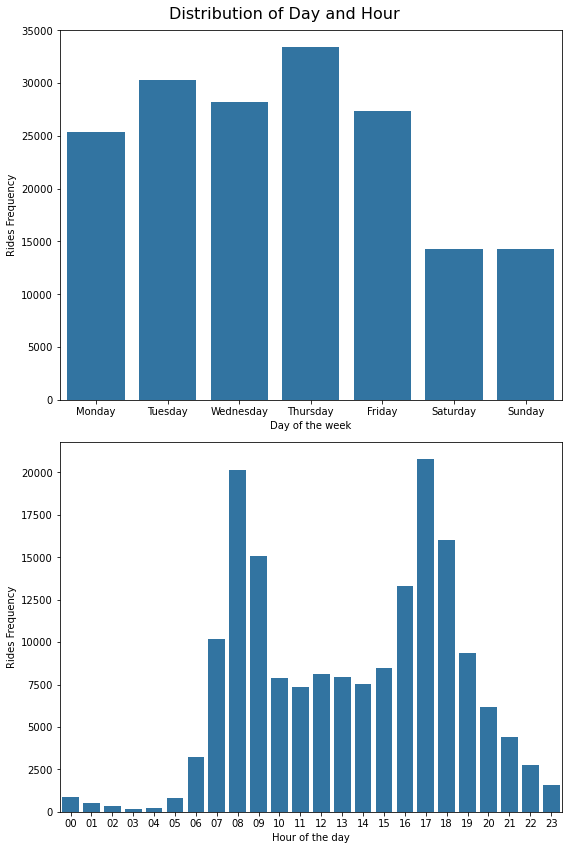

```python
#set subplots
fig, ax = plt.subplots(nrows = 2, figsize = [8,12])

#time characteristic order
hour_order = ['00', '01', '02', '03', '04', '05', '06', '07', '08', '09', '10', '11', '12',
              '13', '14', '15', '16', '17', '18', '19', '20', '21', '22', '23']

#plot the Day, Month and Hour
sb.countplot(data = df, x = 'start_day', ax = ax[0], color = default_color, order = day_order, label = 'data')
sb.countplot(data = df, x = 'start_hour', ax = ax[1], color = default_color, order = hour_order);

#title and labels
fig.suptitle('Distribution of Day and Hour', size = 16);

for a in ax:
    a.set_ylabel('Rides Frequency')

ax[0].set_xlabel('Day of the week')
ax[1].set_xlabel('Hour of the day')

fig.tight_layout();
```

It is clear that thursday and tuesday is the best day for the riders to ride the bikes which are work days and least days is sunday and saturday which are weekends.

Peak hours are 7-9 AM and 4-6 PM. The number of trips is very low between 00:00 to 05:00

Since we have higher ride counts on weekdays and 2 peak hours, maybe the users are students or workers going to school or work and coming back during those peak hours.

We already know that all of the trips are recorded in Febraury so no need to plot the months.

> **Which trip duration range has the most occurance?**

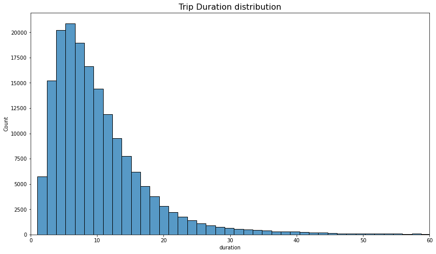

```python
#plotting duration
plt.figure(figsize=(14,8))
plt.xlim(0,60)
plt.title('Trip Duration distribution', size = 16)
sb.histplot(df['duration'], bins=1000);
```

Most of the trips have duration of less than 10 minutes as we can see from the graph above.

> **What age group has the most members?**

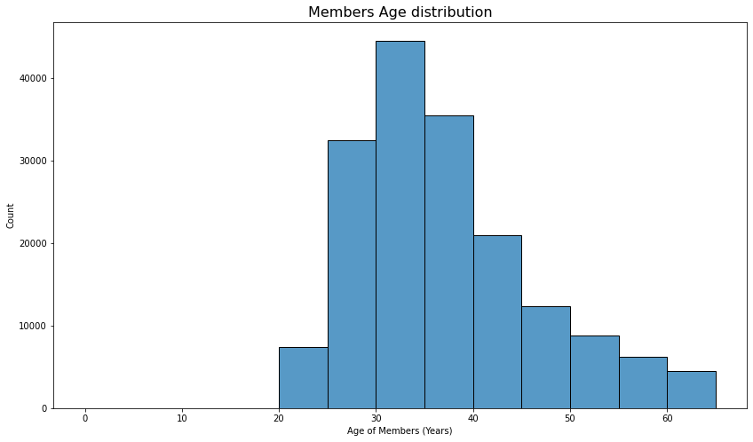

```python
#exploring the age:
bins = np.arange(0, df['member_age'].max(), 5)
plt.figure(figsize = (14,8))
plt.title('Members Age distribution', size = 16)
plt.xlabel('Age of Members (Years)')
sb.histplot(df['member_age'], bins=bins);
```

That's a little bit skewed to the right distribution as it shows age groups from 20 to 45 as leading for renting bike trips.

It is consistent with the probability that those aged 20 - 45 are the most demanding age group for rides as they are the most active population either in work or study.

> **What is the distribution of user type and member genders?**

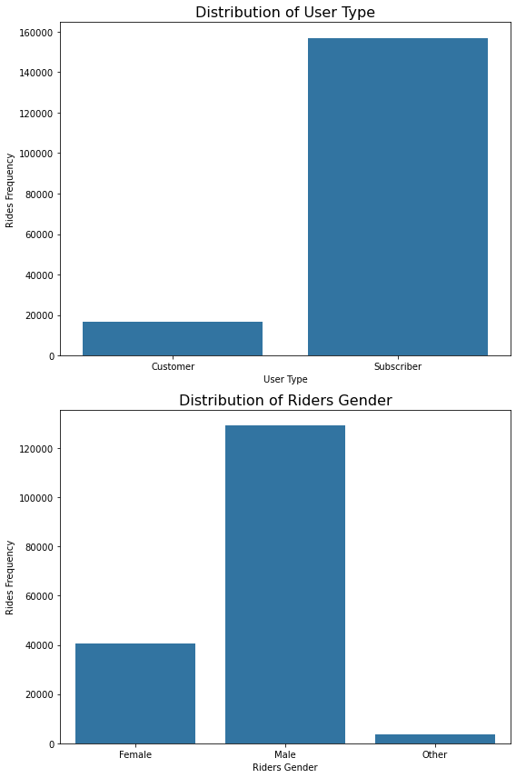

```python
fig, ax = plt.subplots(nrows = 2, figsize = [8,12])
sb.countplot(data = df, x = 'user_type', color = default_color, ax = ax[0])
sb.countplot(data = df, x = 'member_gender', color = default_color, ax = ax[1]);
# title and labels
for a in ax:
    a.set_ylabel('Rides Frequency')

ax[0].set_xlabel('User Type')
ax[0].set_title('Distribution of User Type', size = 16)
ax[1].set_xlabel('Riders Gender')
ax[1].set_title('Distribution of Riders Gender', size = 16)
fig.tight_layout();
```

Subcribers have done more number of rides than Customers. As subscribed member ride price is less than casual customers, this might be the reason for more number of rides. Refer [https://en.wikipedia.org/wiki/Bay_Wheels]

Male riders counts are three times more than the Female riders. Other gender count is lesser when compared to male and female genders

> **What is the distribution of bike sharing on trips for users?**

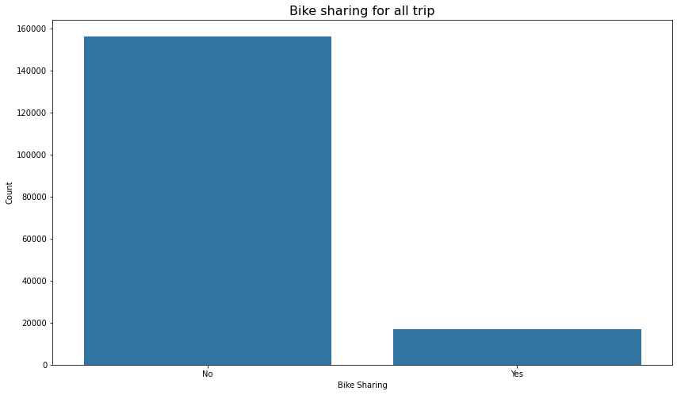

```python
plt.figure(figsize=(14,8))
sb.countplot(data = df, x = 'bike_share_for_all_trip', color = default_color)
xyt('Bike Sharing','Count','Bike sharing for all trip')
```

From the above plot, we find that most users didn't share the bikes for all trip.

> **What are the most popular start stations?**

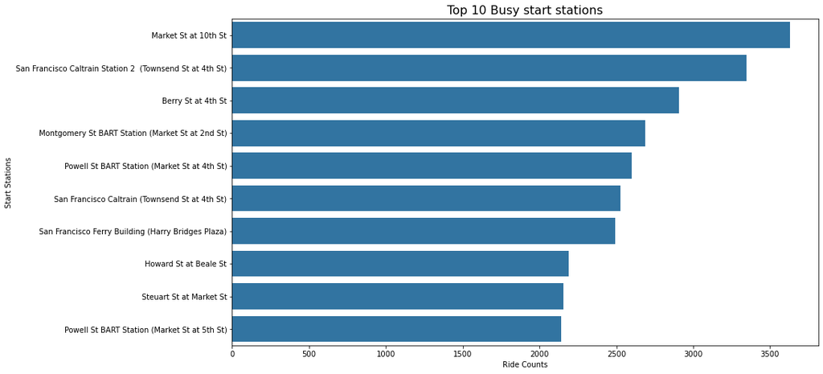

```python
plt.figure(figsize=(14,8))
#most popular start station
counts_start = df.start_station_name.value_counts().nlargest(10)
#slice top 10 data
station_start = df.loc[df.start_station_name.isin(counts_start.index)]
#plot the stations
sb.countplot(data = station_start, y = 'start_station_name', color = default_color, order = counts_start.index);
xyt('Ride Counts','Start Stations','Top 10 Busy start stations')
```

Most commuted start stations are Market St (at 10th St), San Francisco Caltrain Station 2 (Townsend St at 4th St) and Berry St (at 4th St)

> **What are the most popular end stations?**

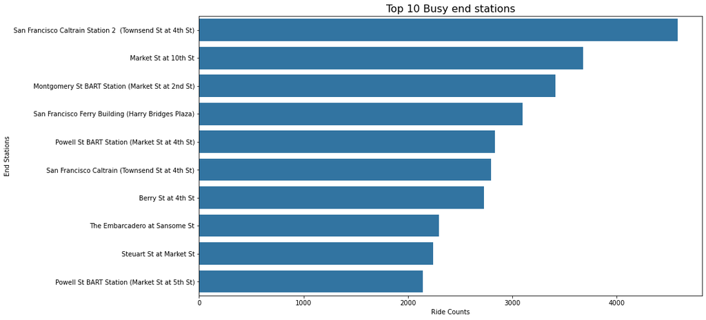

```python
plt.figure(figsize=(14,8))
#most popular end station
counts_end = df.end_station_name.value_counts().nlargest(10)
#slice top 10 data
station_end = df.loc[df.end_station_name.isin(counts_end.index)]
#plot the stations
sb.countplot(data = station_end, y = 'end_station_name', color = default_color, order = counts_end.index)
#set title and label
xyt('Ride Counts','End Stations','Top 10 Busy end stations')
```

Most commuted end stations are San Francisco Caltrain Station 2 (Townsend St at 4th St), Market St (at 10th St) and Montgomery St BART Station (Market St at 2nd St)

### Discuss the distribution(s) of your variable(s) of interest. Were there any unusual points? Did you need to perform any transformations?

> The dataset contains many males than females.

> Subscribers are more than customers.

> We also noticed that peak hours are those from 7 - 9 am and from 4 - 6 pm. This might be related to the time when employees and students go to and leave work and school. This is was also consistent with the distribution of trips over weekdays, where work days have the most demand for trips.

> Age distribution follows any typical age distribution (Skewed to the right). It is consistent with the distribution of weekdays demands for bikes with those aged 20 - 45 are the most demanding segment for rides as they are the most active population either in work or study.

> The vast majority of trips don't engage in bike sharing

### Of the features you investigated, were there any unusual distributions? Did you perform any operations on the data to tidy, adjust, or change the form of the data? If so, why did you do this?

> We created more features from the data data to have more insights of which hour/day are the most when it comes to bike rentals.

> Member age contains ages more than 100 which is exceptional. To avoid this, I have ignored the age range above 67.

## Bivariate Exploration

> In this section we explore relationships between different sets of two variables.

> **What day of the week has the most average trips duration?**

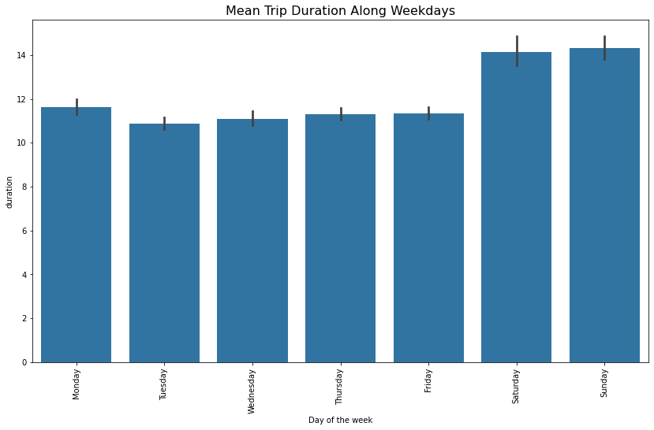

```python
plt.figure(figsize=(14,8))
sb.barplot(data = df, x = 'start_day', y = 'duration', order = day_order, color = default_color)
plt.xlabel("Day of the week")
plt.title("Mean Trip Duration Along Weekdays", size = 16);
plt.xticks(rotation = 90);
```

Mean trip duration is almost the same across weekdays with a notable increase in the weekend.

> **What is the average trip duration for the age groups?**

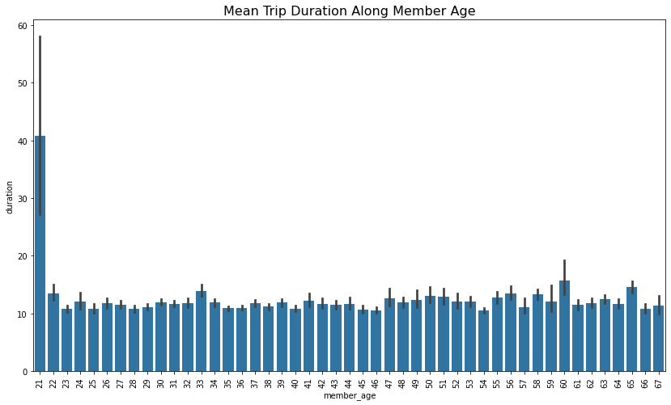

```python
plt.figure(figsize=(14,8))
sb.barplot(data = df, x = 'member_age', y = 'duration', color = default_color)
plt.xticks(rotation = 90);
plt.title("Mean Trip Duration Along Member Age", size = 16);
```

The age with largest average of trip duration are 21 and 60

> **What user type and gender use bike sharing for all trips?**

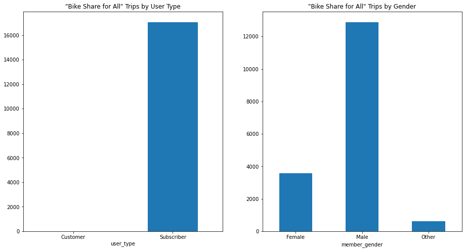

```python
plt.figure(figsize=(24, 8))
ax = plt.subplot(1, 3, 1)
# Number of bike sharing trips by user_type
df.groupby(['user_type', 'bike_share_for_all_trip']).size().unstack()['Yes'].plot(kind = 'bar', ax = ax, title = '"Bike Share for All" Trips by User Type', rot = 0)
ax = plt.subplot(1, 3, 2)
# Number of bike sharing trips by gender
df.groupby(['member_gender', 'bike_share_for_all_trip']).size().unstack()['Yes'].plot(kind = 'bar', ax = ax, title = '"Bike Share for All" Trips by Gender', rot = 0);
```

All "Bike Share for All" trips are taken by Subscribers. Also, the vast majority of "Bike Share for All" trips are taken by males

> **What is the mean trip duration by gender, user type and bike sharing for all trips?**

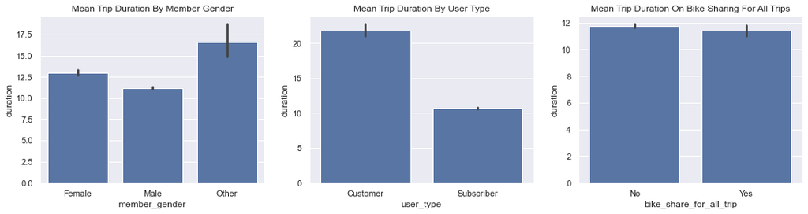

```python
plt.figure(figsize = (24, 4))

plt.subplot(1,4,1)
sb.barplot(data = df, x = 'member_gender', y = 'duration', color = default_color)
#plt.xticks(rotation=90);
plt.title("Mean Trip Duration By Member Gender");

plt.subplot(1,4,2)
sb.barplot(data = df, x = 'user_type', y = 'duration', color = default_color)
#plt.xticks(rotation=90);
plt.title("Mean Trip Duration By User Type");

plt.subplot(1,4,3)
sb.barplot(data = df, x = 'bike_share_for_all_trip', y = 'duration', color = default_color)
#plt.xticks(rotation=90);
plt.title("Mean Trip Duration On Bike Sharing For All Trips");
```

Average trip duration is highest for "Other" gender category.

Trip duration is slightly higher for females than males.

Average trips duration for Customers is double that of Subscribers.

Cyclists in the "Bike Share for All" program take slightly shorter trips than other Cyclists.

> **What is the age range of the different user types?**

[figure not shown]

```python
plt.figure(figsize=(14,8))
plt.title('Trips Durations along Weekdays', size = 16)
sb.boxplot(data = df, x = 'user_type', y = 'member_age');
```

It seems that Subscribers have larger range of age however Customers have slightly younger age range.

> **What is age range of the different genders?**

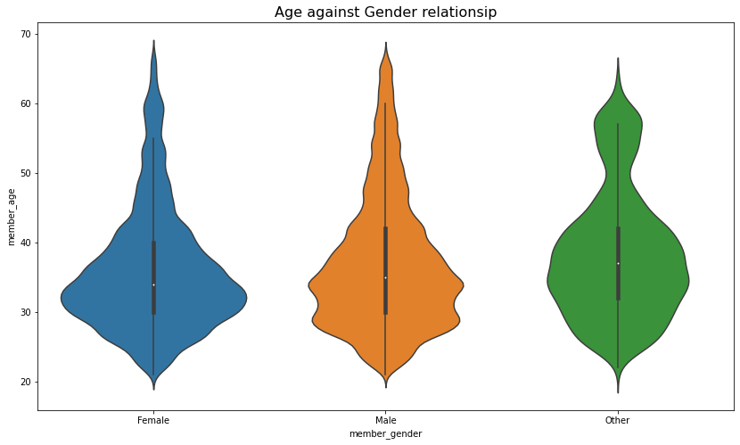

```python
plt.figure(figsize = (14,8))
plt.title('Age against Gender relationsip', size = 16)
sb.violinplot(x = df.member_gender, y = df.member_age);
```

Both Male and Females age ranges have the same age median.

> **What are the most popular stations used by Customers/ Subscribers to rent bikes?**

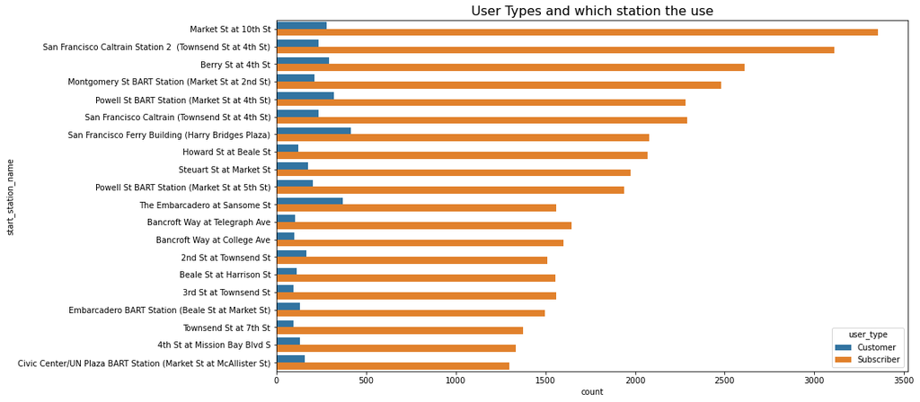

```python
#plotting User types and the relationship with the start station of the trip:
pop_stations = df.start_station_name.value_counts().head(20).index
plt.figure(figsize = (14,8))
plt.title('User Types and which station the use', size = 16)
sb.countplot(y = df.start_station_name, hue = df.user_type, order = pop_stations);
```

Market St and San Francisco Caltrain Station 2 are the two most stations used by Subscribers to rent bikes. On the other hand, San Francisco Ferry Building and The Embarcadero are the most stations used by Customers.

### Talk about some of the relationships you observed in this part of the investigation. How did the feature(s) of interest vary with other features in the dataset?

> The median of both genders (Male/Female) is nearly identical

> Sundays have the most average trips duration

> Customers spend more time than subscribers

### Did you observe any interesting relationships between the other features (not the main feature(s) of interest)?

> All "Bike Share for All" trips are taken by subscribers

> There is a huge gap between the number of subscribers and ustomers for the top used start stations.

## Multivariate Exploration

> Create plots of three or more variables to investigate your data even further.

> **What is the relationship between Weekdays, Average duration, Bike share for all trips and the User Gender?**

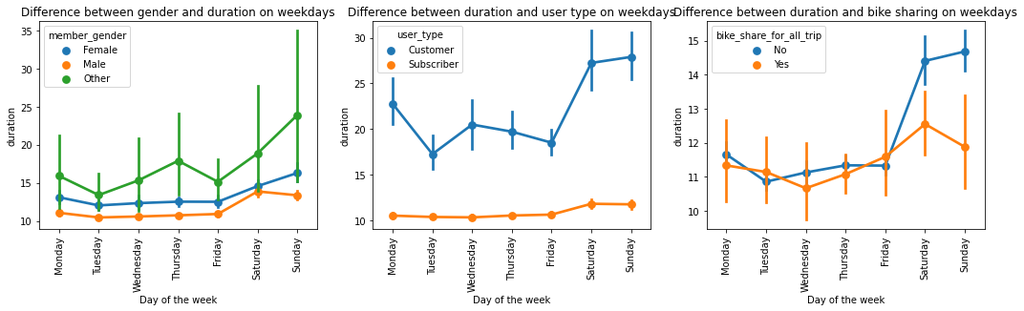

```python
plt.figure(figsize = (24, 4))

plt.subplot(1,4,1)
sb.pointplot(data = df, x = 'start_day', y = 'duration', hue ='member_gender', order = day_order)
plt.xlabel("Day of the week");
plt.title("Difference between gender and duration on weekdays");
plt.xticks(rotation = 90);

plt.subplot(1,4,2)
sb.pointplot(data = df, x = 'start_day', y = 'duration', hue = 'user_type', order = day_order)
plt.xlabel("Day of the week");
plt.title("Difference between duration and user type on weekdays");
plt.xticks(rotation = 90);

plt.subplot(1,4,3)
sb.pointplot(data = df, x = 'start_day', y = 'duration', hue='bike_share_for_all_trip', order = day_order)
plt.xlabel("Day of the week");
plt.title("Difference between duration and bike sharing on weekdays")
plt.xticks(rotation = 90);
```

> **What is the relationship between Weekdays, Member age and the User Gender?**

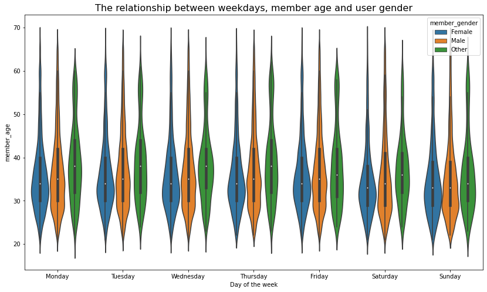

```python
plt.figure(figsize=(14,8))
sb.violinplot(x = df.start_day, y =  df.member_age, hue = df.member_gender, order = day_order)
plt.xlabel("Day of the week")
plt.title('The relationship between weekdays, member age and user gender', size = 16);
```

> **Duration Per User Type and Gender**

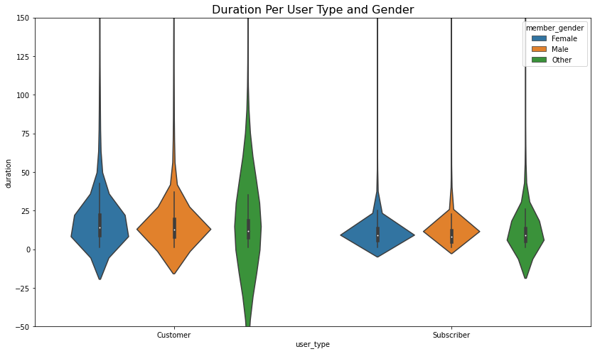

```python
plt.figure(figsize=(14,8))
sb.violinplot(x = df.user_type, y = df.duration, hue = df.member_gender)
plt.ylim([-50, 150])
plt.title('Duration Per User Type and Gender', size = 16);
```

It is clear that the time duration for females is larger than males in both customers and subscribers.

### Talk about some of the relationships you observed in this part of the investigation. Were there features that strengthened each other in terms of looking at your feature(s) of interest?

> Customers have consistently longer trips than subscribers. There is a clear different usage pattern between customers and subscribers in the way we previously explained

> In the bivariate exploration, we've discovered that the trip duration varies extremely between subscribers and customers.

> The trip duration is practically the same for those enrolled in the "Bike Share" program across the week, while it increases considerably for those not enrolled in the program during the weekend compared to the weekdays.

### Were there any interesting or surprising interactions between features?

> The females have much duration time in both types customers and subscribers.

> In both Customer and Subscriber, weekends have the higher trip duration, among which Customer has the highest.

> The average duration of casual users was higher on the weekends days than the rest of the days unlike the subscribers the duration distribution which is uniform even on the weekdays.

## Conclusions

> **The analysis of the dataset provides the following insights:**

> The vast majority of trips are taken by males.

> The vast majority of trips are for cyclists not enrolled in the Bike Share for All program.

> The average trip duration is 12 minutes.

> All "Bike Share for All" trips are taken by Subscribers.

> Most of the trips start at 8AM and at 5PM which is a strong sign that cyclists use our bikes to commute to/from work or school

> Market St and San Francisco Caltrain Station 2 are the two most stations used by subscribers to rent bikes.